# DM Stat Spatiale

MONTES Pierre, THOMASSIN Mathieu

2023-04-06

Nous étudions s’il existe un phénomène d’**autocorrélation spatiale** associé à la part de ménages pauvres dans la ville de **Bordeaux**.

**Import des données:**

```r
# Données carroyées pour la ville de Bordeaux
bordeaux <- st_read("/Users/mathi/Documents/Ensai/2A/S2/Introduction à la statistique spatiale/Donnees/bordeaux.gpkg")
```

```r
#Récupération du fond de communes et filtrage pour extraire les données relatives à Bordeaux
fond_communes <- st_read("C:/Users/mathi/Documents/Ensai/2A/S2/Introduction à la statistique spatiale/Donnees/commune_francemetro_2021/commune_francemetro_2021.shp"
                         , options = "ENCODING=UTF8")

fond_communes_bordeaux <- fond_communes %>%
  filter(libelle=="Bordeaux")
```

**2. Vous représenterez ces données carroyées en superposant le fond de la commune. Les carreaux dépassent-ils les frontières communales ? Si oui, quel intérêt y a-t-il à cela ?**

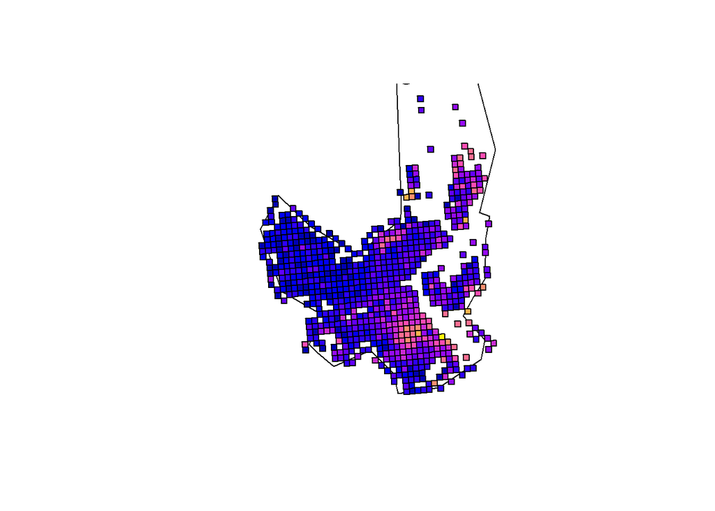

Les carreaux dépassent la frontière communale. L’intersection d’un carreau et de la frontière communale pourrait ne pas comporter suffisamment d’individus et donc violer le secret statistique. La construction des carreaux répond cependant au problème du MAUP. C’est pourquoi on les utilise.

**3. Vous étudierez ensuite s’il existe un phénomène d’autocorrélation spatiale. Vous utiliserez l’ensemble des indicateurs vus en TP, évidemment le I de Moran mais également les indicateurs d’autocorrelation locaux (LISA). Vous testerez pour ces derniers leur significativité. Vous discuterez également des résultats en fonction de la notion de voisinage.**

Comparons la distribution réelle de la variable issue de notre jeu de données avec une distribution aléatoire.

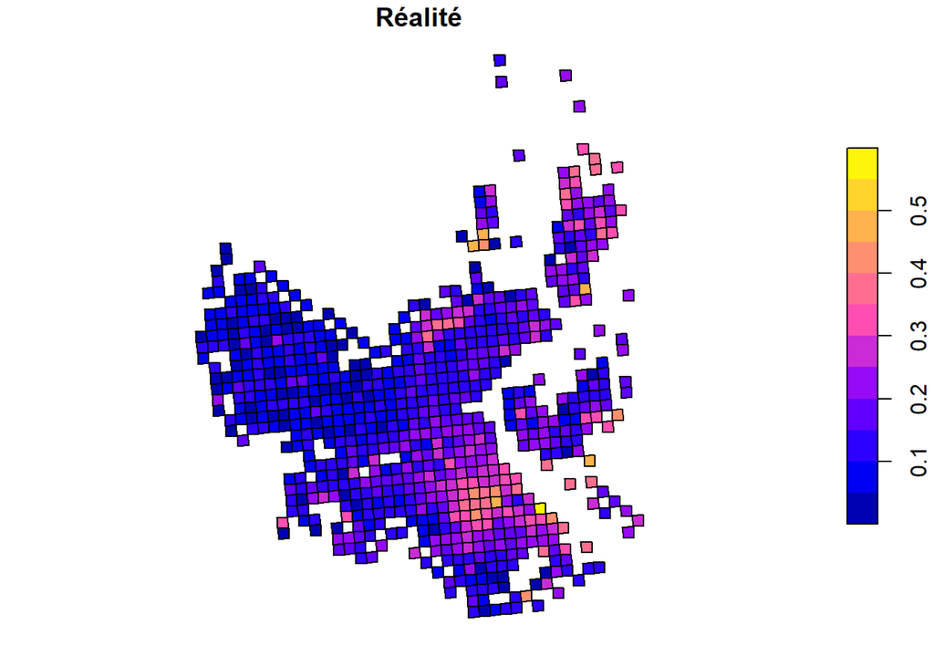

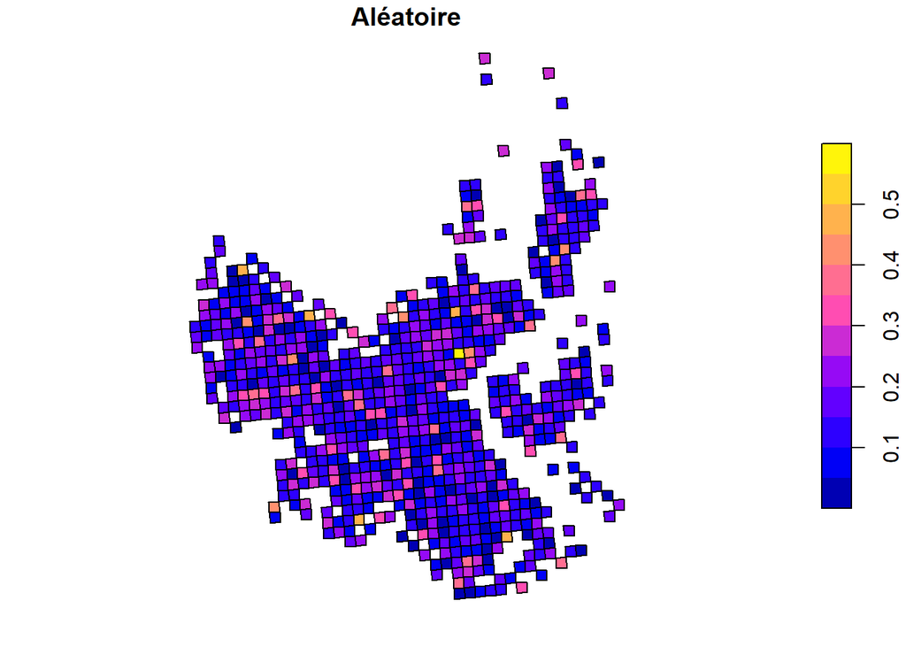

Clairement, la réalité semble présenter un phénomène d’autocorrélation spatiale positive. Les voisins ont tendance à prendre des valeurs similaires. On peut vérifier avec les méthodes quantile et jenks

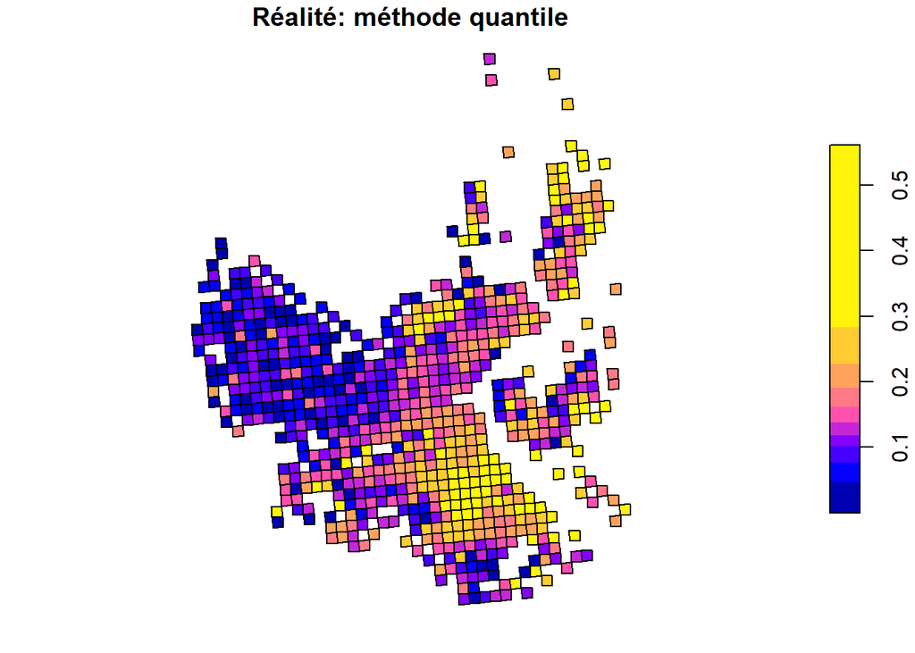

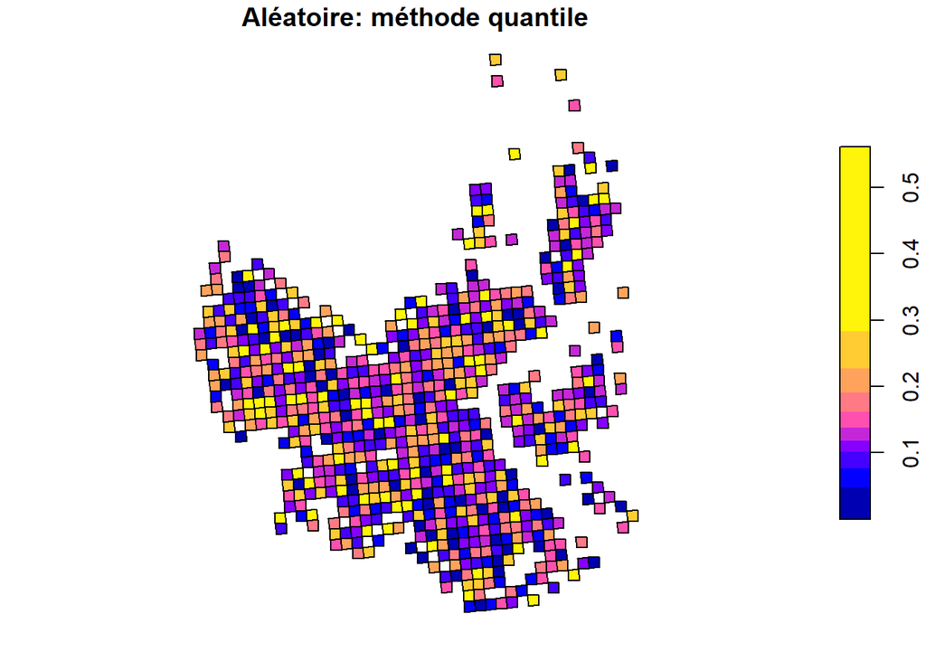

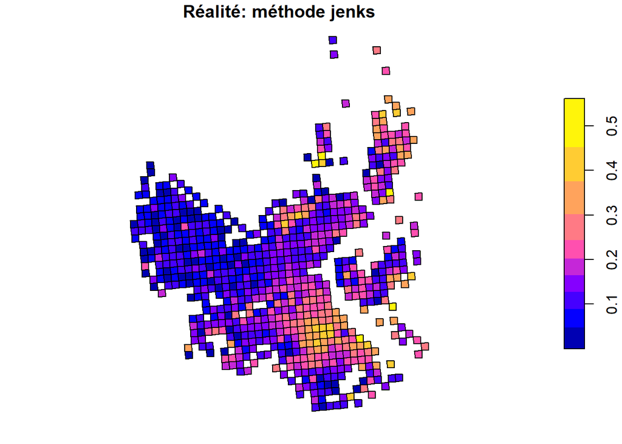

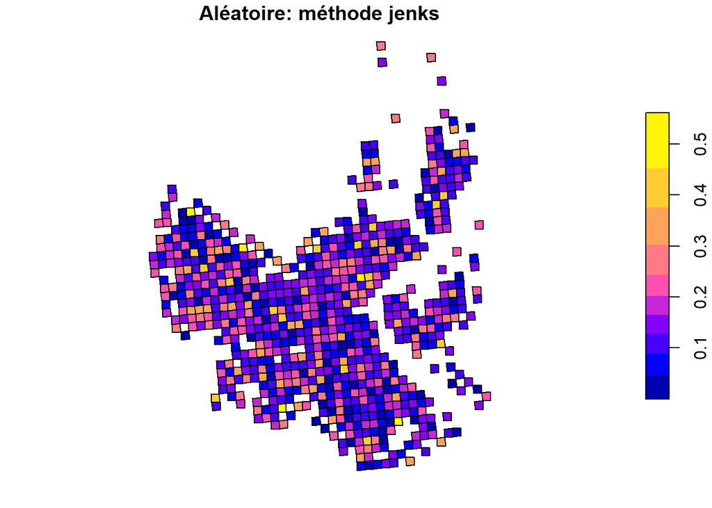

Le constat reste le même.

Pour se donner une meilleure idée, on regarde sur un fonds de carte OpenstreetMap.

[interactive chart not shown]

On observe que les carreaux ayant la part des ménages pauvres la plus élevée se concentrent avant tout autour du quartier de la gare, ainsi que dans une moindre mesure sur la rive droite qui est une zone plus récente avec de nombreuses tours. A l’inverse, l’ouest est constitués d’une plus faible part de ménages pauvres. Il s’agit de quartiers plus résidentiels composés principalement d’“échoppes bordelaises”.

Nous allons étudier le phénomène grâce à une **matrice de voisinage**. Dans un premier temps, nous allons définir le voisinage par la contiguïté : deux carreaux sont **voisins** s’ils sont contigus.

Nous pouvons constater par exemple le nombre de carreaux selon le nombre de voisins

| **nombre de voisins** | **0** | **1** | **2** | **3** | **4** | **5** | **6** | **7** | **8** |
| --- | --- | --- | --- | --- | --- | --- | --- | --- | --- |
| **nombre de carreaux** | 12 | 17 | 29 | 55 | 36 | 66 | 84 | 108 | 351 |

Nous donnons un poids à chaque carreau, égal, et en incluant les carreaux sans voisin.

```r
ponderation <- nb2listw(voisins, zero.policy = TRUE)
str(ponderation, max.level = 1)
summary(str(ponderation, max.level = 1)) #zero.policy=TRUE
```

```r
# On vérifie que la somme des poids est égale à 1
all(sapply(ponderation$weights, sum) == 1)
# Le résultat est FALSE, mais on peut vérifier que c'est le cas pour chaque
# pondération en utilisant str(), sauf pour les carreaux sans voisin.
str(ponderation$weights)
```

```r
# diagramme de Moran, avec une standardisation de la variable.
bordeaux <- bordeaux %>%
  mutate(part_Men_pauv_standardise = scale(part_Men_pauv))
mean(bordeaux$part_Men_pauv_standardise)
sd(bordeaux$part_Men_pauv_standardise)
```

[output not shown]

On a bien une moyenne proche de 0 et une variance égale à 1.

[output not shown]

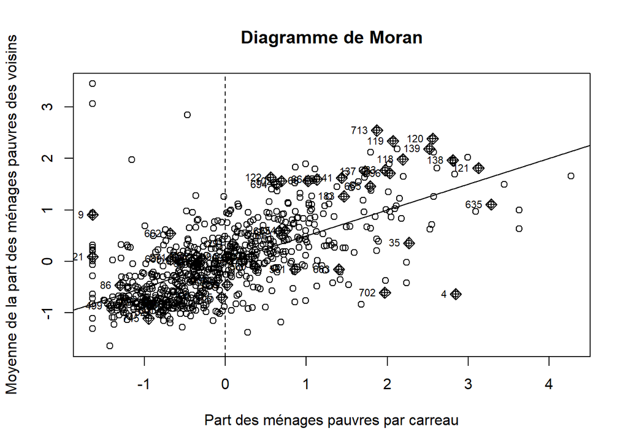

Les observations sont relativement bien alignées selon la première diagonale du plan. Le phénomène semble bien autocorrélé spatialement et cette autocorrélation semble positive. De plus, on observe une concentration des observations dans le cadran low-low (en bas à gauche). Les carreaux avec une faible part de ménages pauvres sont entourés de carreaux ayant une faible part de ménages pauvres.

On réalise une mesure globale du phénomène à travers le I de Moran.

```r
moran.test(bordeaux$part_Men_pauv_standardise
           , ponderation
           , randomisation = TRUE
           , zero.policy = TRUE)
```

[output not shown]

Le I de Moran vaut 0.488, ce qui est une valeur relativement élevée. Le test réalisé est le suivant :

- H0 : le I de Moran est nul, cad le phénomène n’est pas spatialement autocorrélé.
- H1 : I > 0 (par défaut - en effet on soupçonne une autocorrélation positive - cette alternative est préférable) Ici, la p-valeur est très faible, conduisant à rejeter l’hypothèse nulle et donc à conclure/confirmer l’autocorrélation spatiale positive au sein du phénomène.

**Etude des LISA**

Rappel: Pour chaque observation, ils indiquent l’intensité du regroupement de valeurs similaires (ou de tendances opposées) autour de cette observation.

```r
lisa_bordeaux <- spdep::localmoran(bordeaux$part_Men_pauv
                                   , ponderation, zero.policy = TRUE)
class(lisa_bordeaux)
str(lisa_bordeaux, max.level = 1)
summary(lisa_bordeaux)
```

```r
mean(lisa_bordeaux[,1])
```

```
## [1] 0.488241
```

On remarque que la moyenne de Lisa est égale au I de Moran global. En effet, les Lisa sont construits de telle sorte que leur somme soit proportionnelle au I de Moran global.

```
##
## FALSE  TRUE
##   159   599
```

Nous avons 599 carreaux qui ont un LISA positif, contre 159 négatifs. Cela confirme notre hypothèse de présence d’une autocorrélation positive.

Représentons les LISA sur la carte:

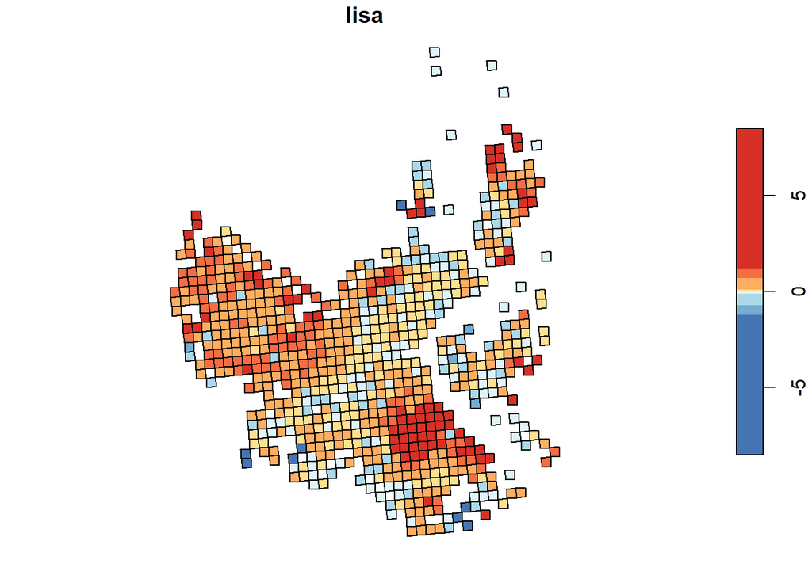

On observe à nouveau un phénomène de regroupement des valeurs similaires de la part des ménages pauvres dans le quartier de la gare, dans le nord-ouest résidentiel ainsi que dans l’extrême nord-est de la ville.

Il faut néanmoins savoir si les Lisa calculés sont significativement différents de zéro

On se place à un niveau de confiance de 95%

```
##
## FALSE  TRUE
##   497   249
```

```
##    Min. 1st Qu.  Median    Mean 3rd Qu.    Max.    NA's
## 0.00000 0.02643 0.18365 0.30685 0.54152 0.99873      12
```

Nous constatons que 249 carreaux ont un lisa significativement différent de 0 au seuil de 5%.

**Visualisation des p_values.**

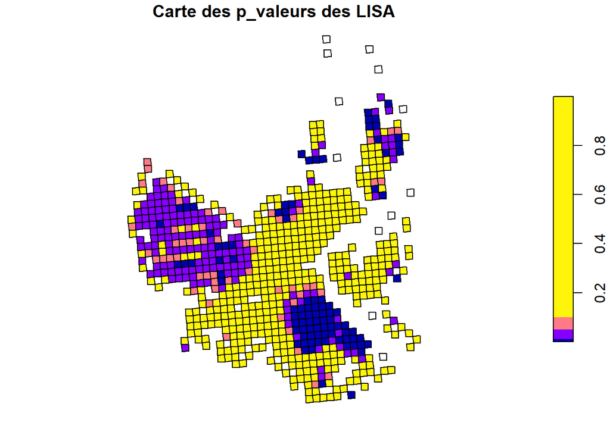

Nous confirmons notre analyse, à savoir que Bordeaux présente trois zones regroupant des parts de ménages pauvres similaires: quartier de la gare, nord-ouest résidentiel et extrême nord-est.

### Méthode de Bonferroni

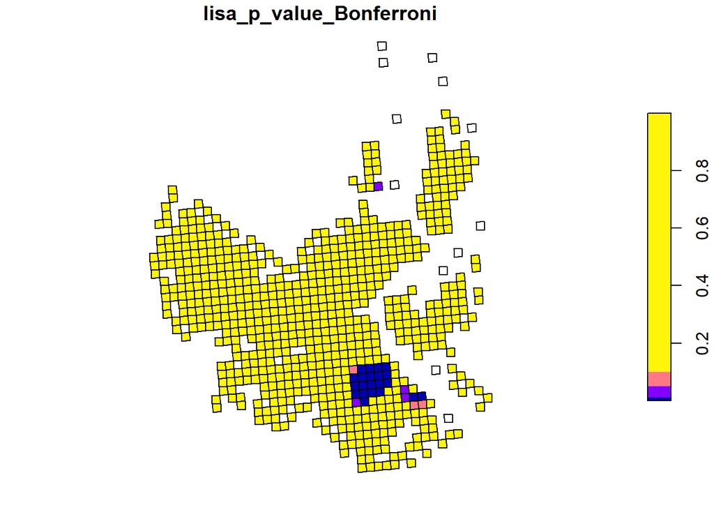

### Méthode de Holm

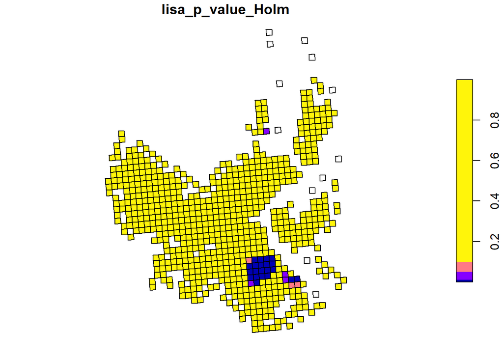

Les deux méthodes renvoient des cartes très similaires. Cependant, nous n’observons plus qu’une seule zone ayant un seuil de significativité élevé. Il s’agit du quartier de la gare, celui qui semblait montrer le plus d’autocorrélation spatiale.

### DISCUSSION des résultats en fonction de la notion de voisinage:

Nous nous sommes concentrés sur une seule définition du voisinage, entendu comme contiguïté. Nous pourrions envisager que le voisinage d’une observation ne s’arrête pas qu’aux observations partageant une frontière commune. En effet, nous pourrions considérer qu’est voisine d’une observation donnée, toute observation située dans un rayon de X km.

Dans ce cas, il faut définir une distance (distance euclidienne à vol d’oiseau; distance en temps de parcours par la route; k-plus-proches-voisins, etc.) pour définir l’éloignement des observations entre elles, et un seuil délimitant le rayon de voisinage. En définissant ainsi le voisinage, il n’est pas raisonnable d’attribuer le même poids d’influence à toutes les observations du voisinage : on attribuera un poids plus fort aux voisins les plus proches.

Classiquement, le poids des voisins est défini par l’inverse de la distance. Mais d’autres choix sont possibles.

La notion de voisinage pourrait également être redéfinie en fonction des infrastructures de mobilités et de la géographie. En effet, Bordeaux est traversée par la Garonne, ce qui a pour effet de couper la ville sur un axe nord-sud et de ne laisser que les 7 ponts comme points de passage. Il pourrait être également possible d’utiliser les temps de trajet selon différents modes de transport.